# Bellabeat Project

Koki Nishida

2023-07-31

[figure not shown]

In this project, I will showcase my process of data analysis using R.

# Scenario

You are a junior data analyst working on the marketing analyst team at Bellabeat, a high-tech manufacturer of health-focused products for women. Bellabeat is a successful small company, but they have the potential to become a larger player in the global smart device market. Urška Sršen, cofounder and Chief Creative Officer of Bellabeat, believes that analyzing smart device fitness data could help unlock new growth opportunities for the company. You have been asked to focus on one of Bellabeat’s products and analyze smart device data to gain insight into how consumers are using their smart devices. The insights you discover will then help guide marketing strategy for the company.

## Business Task

To analyze smart device usage data in order to gain insight into how consumers use non-Bellabeat smart devices.

# Ask

- What are some trends in smart device usage?
- How could these trends apply to Bellabeat customers?
- How could these trends help influence Bellabeat marketing strategy?

# Prepare

We will be using Fitbit Fitness Tracker Data [link](https://www.kaggle.com/datasets/arashnic/fitbit) that contains personal fitness tracker from 30 fitbit users. Thirty eligible Fitbit users consented to the submission of personal tracker data, including minute-level output for physical activity, heart rate, and sleep monitoring. It includes information about daily activity, steps, and heart rate that can be used to explore users’ habits.

## ROCCC analysis

```r
# install and load packages
library(tidyverse)
library(janitor)
library(skimr)
library(lubridate)
```

# Process

```r
daily_activity <- read.csv("Fitabase Data 4.12.16-5.12.16/dailyActivity_merged.csv")
daily_sleep <- read.csv("Fitabase Data 4.12.16-5.12.16/sleepDay_merged.csv")
weight_log <- read.csv("Fitabase Data 4.12.16-5.12.16/weightLoginfo_merged.csv")
```

```r
# preview data
str(daily_activity)
```

```
## 'data.frame':    940 obs. of  15 variables:
##  $ Id                      : num  1.5e+09 1.5e+09 1.5e+09 1.5e+09 1.5e+09 ...
##  $ ActivityDate            : chr  "4/12/2016" "4/13/2016" "4/14/2016" "4/15/2016" ...
##  $ TotalSteps              : int  13162 10735 10460 9762 12669 9705 13019 15506 10544 9819 ...
##  $ TotalDistance           : num  8.5 6.97 6.74 6.28 8.16 ...
##  $ TrackerDistance         : num  8.5 6.97 6.74 6.28 8.16 ...
##  $ LoggedActivitiesDistance: num  0 0 0 0 0 0 0 0 0 0 ...
##  $ VeryActiveDistance      : num  1.88 1.57 2.44 2.14 2.71 ...
##  $ ModeratelyActiveDistance: num  0.55 0.69 0.4 1.26 0.41 ...
##  $ LightActiveDistance     : num  6.06 4.71 3.91 2.83 5.04 ...
##  $ SedentaryActiveDistance : num  0 0 0 0 0 0 0 0 0 0 ...
##  $ VeryActiveMinutes       : int  25 21 30 29 36 38 42 50 28 19 ...
##  $ FairlyActiveMinutes     : int  13 19 11 34 10 20 16 31 12 8 ...
##  $ LightlyActiveMinutes    : int  328 217 181 209 221 164 233 264 205 211 ...
##  $ SedentaryMinutes        : int  728 776 1218 726 773 539 1149 775 818 838 ...
##  $ Calories                : int  1985 1797 1776 1745 1863 1728 1921 2035 1786 1775 ...
```

```r
str(daily_sleep)
```

```
## 'data.frame':    413 obs. of  5 variables:
##  $ Id                : num  1.5e+09 1.5e+09 1.5e+09 1.5e+09 1.5e+09 ...
##  $ SleepDay          : chr  "4/12/2016 12:00:00 AM" "4/13/2016 12:00:00 AM" "4/15/2016 12:00:00 AM" "4/16/2016 12:00:00 AM" ...
##  $ TotalSleepRecords : int  1 2 1 2 1 1 1 1 1 1 ...
##  $ TotalMinutesAsleep: int  327 384 412 340 700 304 360 325 361 430 ...
##  $ TotalTimeInBed    : int  346 407 442 367 712 320 377 364 384 449 ...
```

```r
str(weight_log)
```

```
## 'data.frame':    67 obs. of  8 variables:
##  $ Id            : num  1.50e+09 1.50e+09 1.93e+09 2.87e+09 2.87e+09 ...
##  $ Date          : chr  "5/2/2016 11:59:59 PM" "5/3/2016 11:59:59 PM" "4/13/2016 1:08:52 AM" "4/21/2016 11:59:59 PM" ...
##  $ WeightKg      : num  52.6 52.6 133.5 56.7 57.3 ...
##  $ WeightPounds  : num  116 116 294 125 126 ...
##  $ Fat           : int  22 NA NA NA NA 25 NA NA NA NA ...
##  $ BMI           : num  22.6 22.6 47.5 21.5 21.7 ...
##  $ IsManualReport: chr  "True" "True" "False" "True" ...
##  $ LogId         : num  1.46e+12 1.46e+12 1.46e+12 1.46e+12 1.46e+12 ...
```

```r
#format column names
daily_activity<- clean_names(daily_activity)
daily_sleep <- clean_names(daily_sleep)
weight_log <- clean_names(weight_log)
# format date
daily_activity$activity_date <- as.Date(daily_activity$activity_date,'%m/%d/%y')
daily_sleep$sleep_day <- as.Date(daily_sleep$sleep_day,'%m/%d/%y')
weight_log $date <- parse_date_time(weight_log$date, '%m/%d/%y %H:%M:%S %p')
# format logical
weight_log$is_manual_report <- as.logical(weight_log$is_manual_report)
head(weight_log)
```

```
##           id                date weight_kg weight_pounds fat   bmi
## 1 1503960366 2016-05-02 23:59:59      52.6      115.9631  22 22.65
## 2 1503960366 2016-05-03 23:59:59      52.6      115.9631  NA 22.65
## 3 1927972279 2016-04-13 01:08:52     133.5      294.3171  NA 47.54
## 4 2873212765 2016-04-21 23:59:59      56.7      125.0021  NA 21.45
## 5 2873212765 2016-05-12 23:59:59      57.3      126.3249  NA 21.69
## 6 4319703577 2016-04-17 23:59:59      72.4      159.6147  25 27.45
##   is_manual_report       log_id
## 1             TRUE 1.462234e+12
## 2             TRUE 1.462320e+12
## 3            FALSE 1.460510e+12
## 4             TRUE 1.461283e+12
## 5             TRUE 1.463098e+12
## 6             TRUE 1.460938e+12
```

```r
# check for duplicates
duplicates <- sum(duplicated(daily_activity))
duplicates1 <- sum(duplicated(daily_sleep))
duplicates2 <- sum(duplicated(weight_log))
# daily_sleep contains duplicates
daily_sleep <- unique(daily_sleep)
# check for nulls
daily_sleep <- na.omit(daily_sleep)
# check for incorrect data
criteria <- daily_activity$total_steps >=0 & daily_activity$total_distance >= 0
daily_activity <- daily_activity[criteria,]
```

```r
# add weekday in daily_activity
daily_activity$day_of_week <- wday(daily_activity$activity_date,label=T,abbr=T)
# sum up active hours
daily_activity$total_active_hours = round((daily_activity$very_active_minutes+daily_activity$fairly_active_minutes+daily_activity$lightly_active_minutes)/60, digits = 2)
# sedentary hours
daily_activity$sedentary_hours = round((daily_activity$sedentary_minutes)/60, digits = 2)

#time taken to fall asleep
daily_sleep$hours_in_bed = round((daily_sleep$total_time_in_bed)/60, digits = 2)
daily_sleep$hours_asleep = round((daily_sleep$total_minutes_asleep)/60,digits = 2)
daily_sleep$time_taken_to_sleep = (daily_sleep$hours_in_bed - daily_sleep$hours_asleep)
 # remove fat column
weight_log <- weight_log %>%
  select(-c(fat))
# add new column that indicates users health status
weight_log <- weight_log %>%
  mutate(bmi2 = case_when(
    bmi > 24.9 ~'Overweight',
    bmi< 18.5~'Underweight',
    TRUE ~ 'Healthy'
  )
  )
```

```r
# remove values where total_active_hours = 0 and calories burned = 0
daily_activity_cleaned <- daily_activity[!(daily_activity$calories <= 0),]
daily_activity_cleaned <- daily_activity_cleaned[!(daily_activity_cleaned$total_active_hours <= 0.00),]


# Export data
write.csv(daily_activity_cleaned, file = "daily_activity.csv", row.names=TRUE)
write.csv(daily_sleep, file = "daily_sleep.csv", row.names=TRUE)
write.csv(weight_log, file = "weight_log.csv", row.names=TRUE)
```

# Analyze

We will perform analysis in R using the ggplot package. Based on the business tasks, we will answer these questions.

1. Calculate the average of steps taken, active minutes, sedentary hours, and sleep hours
2. Which day during the week are users most active?
3. Calories burned vs. active hours, steps, sedentary hours
4. Weight vs. steps taken

## Code

```r
summary(daily_activity_cleaned$total_steps)
```

```
##    Min. 1st Qu.  Median    Mean 3rd Qu.    Max.
##       0    4920    8053    8319   11100   36019
```

```r
summary(daily_activity_cleaned$very_active_minutes)
```

```
##    Min. 1st Qu.  Median    Mean 3rd Qu.    Max.
##    0.00    0.00    7.00   23.21   36.00  210.00
```

```r
summary(daily_activity_cleaned$sedentary_hours)
```

```
##    Min. 1st Qu.  Median    Mean 3rd Qu.    Max.
##    0.00   12.02   17.00   15.87   19.80   23.98
```

```r
summary(daily_sleep$hours_asleep)
```

```
##    Min. 1st Qu.  Median    Mean 3rd Qu.    Max.
##   0.970   6.020   7.210   6.987   8.170  13.270
```

Some takeaways: - The mean steps taken was 8319 steps which is in the somewhat active range 7500-9999. The lower quartile does not meet the range.

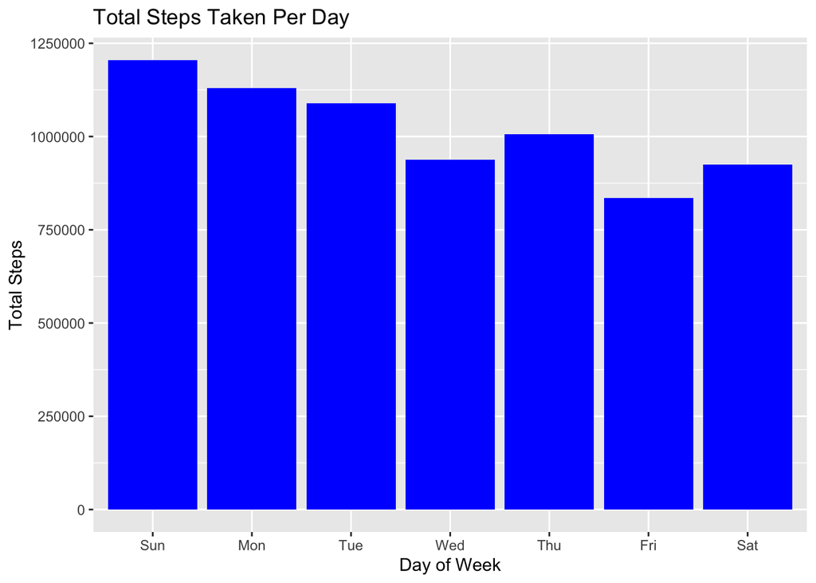

```r
# analyze activity per day
ggplot(data=daily_activity_cleaned, mapping = aes(x=day_of_week,y=total_steps)) + geom_col(fill='blue') + labs(x='Day of Week',y='Total Steps',title='Total Steps Taken Per Day')
```

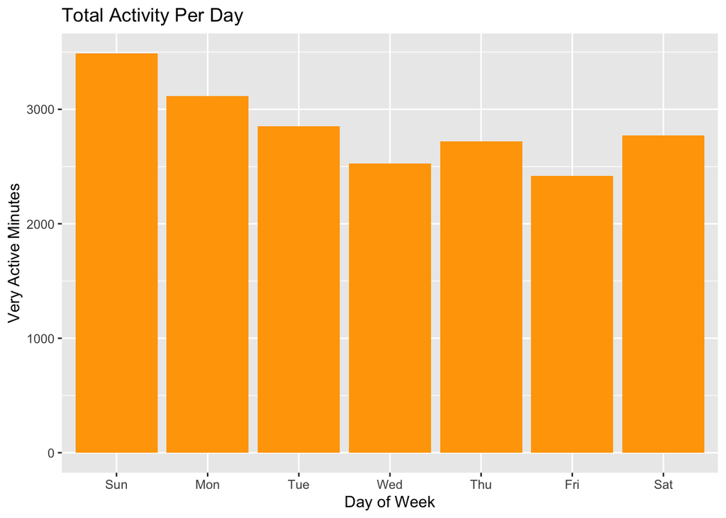

```r
ggplot(data=daily_activity_cleaned, mapping = aes(x=day_of_week,y=very_active_minutes)) + geom_col(fill='orange') + labs(x='Day of Week',y='Very Active Minutes',title='Total Activity Per Day')
```

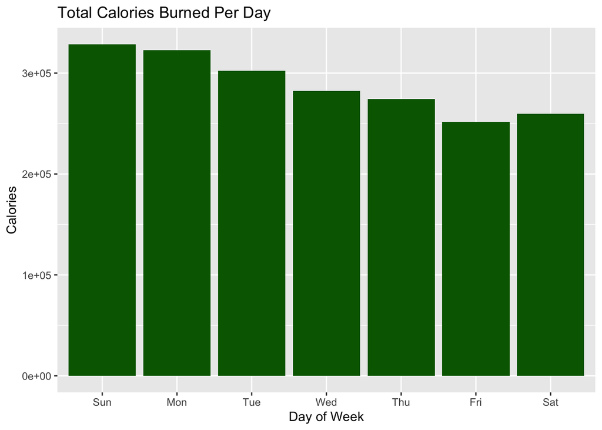

```r
ggplot(data=daily_activity_cleaned, mapping = aes(x=day_of_week,y=calories)) + geom_col(fill='darkgreen') + labs(x='Day of Week',y='Calories',title='Total Calories Burned Per Day')
```

The most active day during the week is Sunday. There is a declining trend from Monday to Friday. This could be possible due to fatigue and motivation from work.

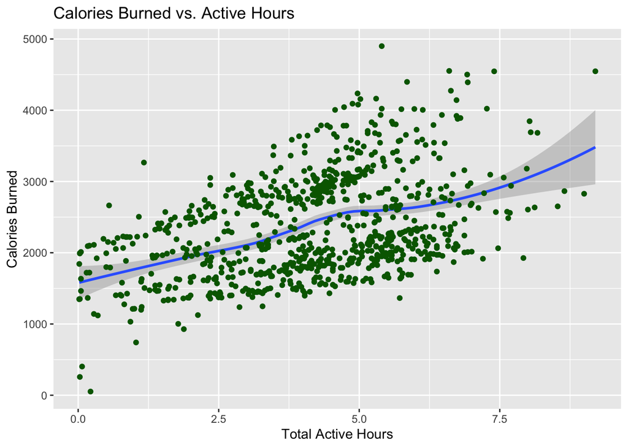

```r
# Analyze Calories vs. active hours, steps, sedentary hours

ggplot(data = daily_activity_cleaned, mapping=aes(x=total_active_hours,y=calories)) + geom_smooth() + geom_point(color='darkgreen') + labs(x='Total Active Hours', y='Calories Burned', title = 'Calories Burned vs. Active Hours')
```

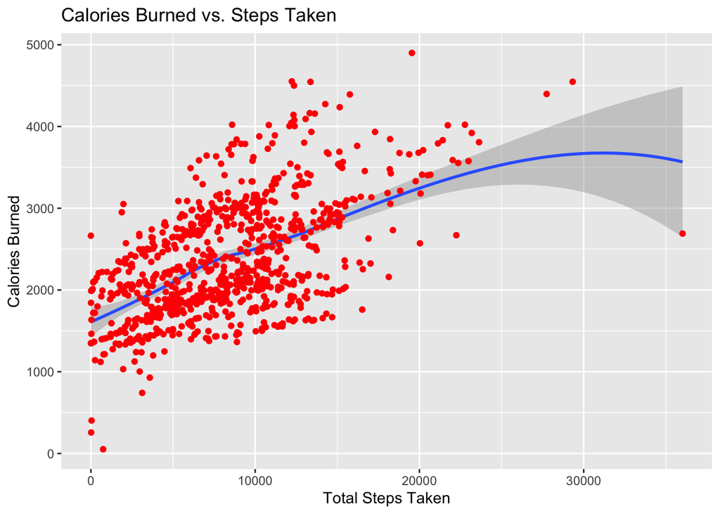

```r
ggplot(data = daily_activity_cleaned, mapping=aes(x=total_steps,y=calories)) + geom_smooth() + geom_point(color='red') + labs(x='Total Steps Taken', y='Calories Burned', title = 'Calories Burned vs. Steps Taken')
```

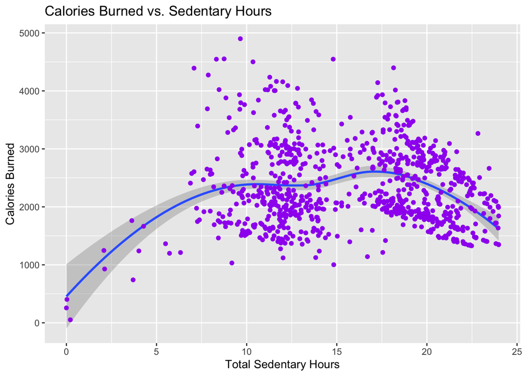

```r
ggplot(data = daily_activity_cleaned, mapping=aes(x=sedentary_hours,y=calories)) + geom_smooth() + geom_point(color='purple') + labs(x='Total Sedentary Hours', y='Calories Burned', title = 'Calories Burned vs. Sedentary Hours')
```

We found a positive correlation between calories burned and total active hours/total steps as expected. The more active people are, the more exercise they are getting and thus leads to more calories burned.

However, the correlation betweem sedentary hours and calories burned is quite complicated. Looking at the overall picture, we can see that most people fall within 1000 to 3000 calories no matter the amount of sedentary hours. It is reasonable to assume that people burn their calories in different ways and need different sedentary hours.

Now, for weight analysis, we must merge the tables.

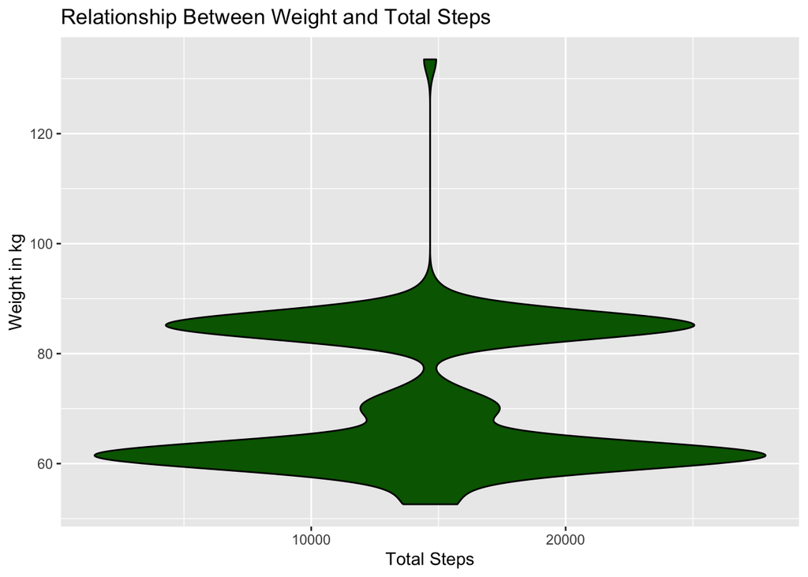

```r
activity_weight<- merge(daily_activity_cleaned, weight_log, by=c('id'))
# now get rid of duplicates
activity_weight<-unique(activity_weight)
#export it
write.csv(activity_weight, file = "activity_weight.csv", row.names=TRUE)

ggplot(data=activity_weight, mapping=aes(x=total_steps,y=weight_kg))+ geom_violin(color='black',fill='darkgreen') + labs(x='Total Steps',y='Weight in kg',title='Relationship Between Weight and Total Steps')
```

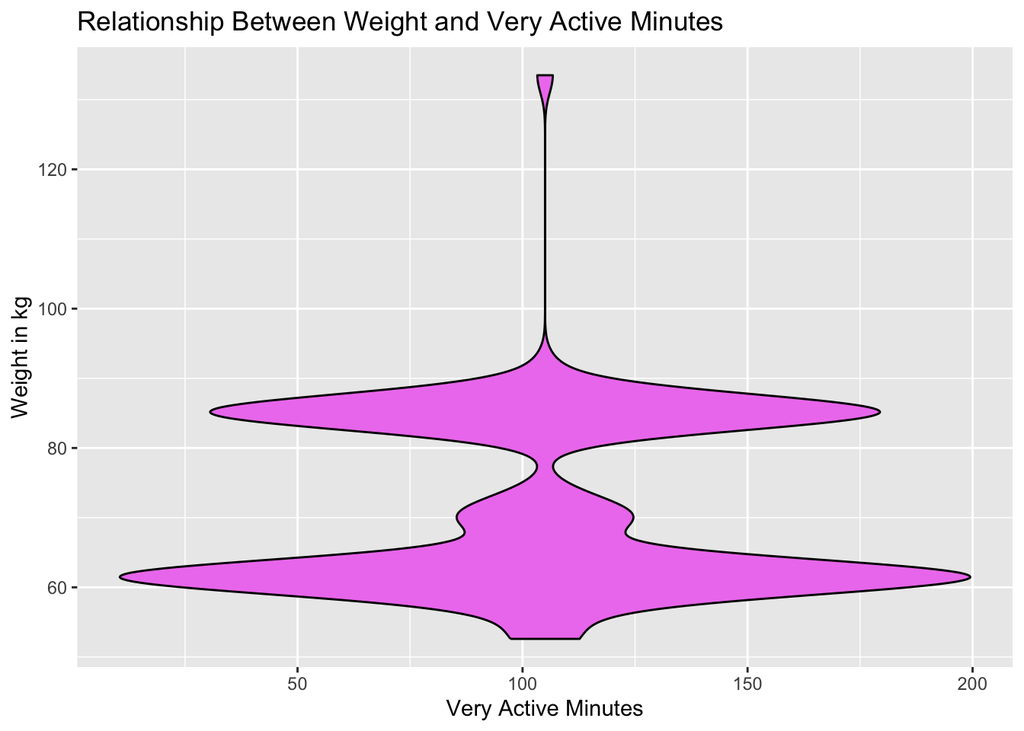

```r
ggplot(data=activity_weight, mapping=aes(x=very_active_minutes,y=weight_kg))+ geom_violin(color='black',fill='violet') + labs(x='Very Active Minutes',y='Weight in kg',title='Relationship Between Weight and Very Active Minutes')
```

# Share

# Act

After analysis, we found that users spend more time engaged in physical activities on Sundays. Throughout the week, the activity declines with a slight peak on Thursdays and a slow increase on Saturday.

Hypothesis:

Most people have more free time on the weekends and are more motivated to workout and get some exercise. Weekdays are most busy for people with work and we see a consistent and low activity on Friday. Fridays are assumed to be the day with most people hanging out and engaged in activities as the end of the week.

Recommendations for Bellabeat’s marketing strategy:

- Bellabeat could implement a reward system to those who meet a goal everyday such as product discounts. This will both help bring new customers and increase activity for existing customers.
- On Fridays, there can be user competition/goal for points to which they can exchange for products to encourage people to keep up their workouts on Fridays too.
- Post motivational/before-after videos and promotions.